# Tugas 3 MPDW

## Pemodelan DLM & ARDL dengan Library `dynlm`

Pemodelan regresi dengan peubah *lag* tidak hanya dapat dilakukan dengan fungsi pada *packages* `dLagM` , tetapi terdapat *packages* `dynlm` yang dapat digunakan. Fungsi `dynlm` secara umum adalah sebagai berikut.

```r
dynlm(formula, data, subset, weights, na.action, method = "qr",
  model = TRUE, x = FALSE, y = FALSE, qr = TRUE, singular.ok = TRUE,
  contrasts = NULL, offset, start = NULL, end = NULL, ...)
```

Untuk menentukan `formula` model yang akan digunakan, tersedia fungsi tambahan yang memungkinkan spesifikasi dinamika (melalui `d()` dan `L()`) atau pola linier/siklus dengan mudah (melalui `trend()`, `season()`, dan `harmon()`). Semua fungsi formula baru mengharuskan argumennya berupa objek deret waktu (yaitu, `"ts"` atau `"zoo"`).

```r
#sama dengan model dlm q=1
cons_lm1 <- dynlm(yt ~ xt+L(xt),data = train.ts)
#sama dengan model ardl p=1 q=0
cons_lm2 <- dynlm(yt ~ xt+L(yt),data = train.ts)
#sama dengan ardl p=1 q=1
cons_lm3 <- dynlm(yt ~ xt+L(xt)+L(yt),data = train.ts)
#sama dengan dlm p=2
cons_lm4 <- dynlm(yt ~ xt+L(xt)+L(xt,2),data = train.ts)
```

### Ringkasan Model

```r
summary(cons_lm1)
```

```
##
## Time series regression with "ts" data:
## Start = 2, End = 15
##
## Call:
## dynlm(formula = yt ~ xt + L(xt), data = train.ts)
##
## Residuals:
##    Min     1Q Median     3Q    Max
##  -8042  -2279   1048   2431   4822
##
## Coefficients:
##              Estimate Std. Error t value Pr(>|t|)
## (Intercept) 60943.053  12981.385   4.695 0.000656 ***
## xt            -12.633      8.055  -1.568 0.145101
## L(xt)          -1.605      8.835  -0.182 0.859192
## ---
## Signif. codes:  0 '***' 0.001 '**' 0.01 '*' 0.05 '.' 0.1 ' ' 1
##
## Residual standard error: 4212 on 11 degrees of freedom
## Multiple R-squared:  0.2052, Adjusted R-squared:  0.06071
## F-statistic:  1.42 on 2 and 11 DF,  p-value: 0.2827
```

```r
summary(cons_lm2)
```

```
##
## Time series regression with "ts" data:
## Start = 2, End = 15
##
## Call:
## dynlm(formula = yt ~ xt + L(yt), data = train.ts)
##
## Residuals:
##      Min       1Q   Median       3Q      Max
## -2447.25  -538.92    99.12   740.32  2980.44
##
## Coefficients:
##               Estimate Std. Error t value Pr(>|t|)
## (Intercept)  1.336e+04  6.400e+03   2.088   0.0608 .
## xt          -4.258e+00  2.974e+00  -1.432   0.1800
## L(yt)        8.338e-01  9.675e-02   8.618  3.2e-06 ***
## ---
## Signif. codes:  0 '***' 0.001 '**' 0.01 '*' 0.05 '.' 0.1 ' ' 1
##
## Residual standard error: 1515 on 11 degrees of freedom
## Multiple R-squared:  0.8972, Adjusted R-squared:  0.8785
## F-statistic: 47.98 on 2 and 11 DF,  p-value: 3.688e-06
```

```r
summary(cons_lm3)
```

```
##
## Time series regression with "ts" data:
## Start = 2, End = 15
##
## Call:
## dynlm(formula = yt ~ xt + L(xt) + L(yt), data = train.ts)
##
## Residuals:
##      Min       1Q   Median       3Q      Max
## -2559.48  -437.27    45.46   337.56  3093.93
##
## Coefficients:
##               Estimate Std. Error t value Pr(>|t|)
## (Intercept) 10460.5444  7644.2130   1.368    0.201
## xt             -4.7254     3.1046  -1.522    0.159
## L(xt)           2.4057     3.2815   0.733    0.480
## L(yt)           0.8444     0.0999   8.452 7.25e-06 ***
## ---
## Signif. codes:  0 '***' 0.001 '**' 0.01 '*' 0.05 '.' 0.1 ' ' 1
##
## Residual standard error: 1548 on 10 degrees of freedom
## Multiple R-squared:  0.9024, Adjusted R-squared:  0.8731
## F-statistic: 30.82 on 3 and 10 DF,  p-value: 2.297e-05
```

```r
summary(cons_lm4)
```

```
##
## Time series regression with "ts" data:
## Start = 3, End = 15
##
## Call:
## dynlm(formula = yt ~ xt + L(xt) + L(xt, 2), data = train.ts)
##
## Residuals:
##     Min      1Q  Median      3Q     Max
## -5911.1 -1572.2   433.9  2247.3  4352.4
##
## Coefficients:
##              Estimate Std. Error t value Pr(>|t|)
## (Intercept) 61825.713  14147.868   4.370   0.0018 **
## xt            -10.534      7.119  -1.480   0.1731
## L(xt)          -5.110      7.927  -0.645   0.5353
## L(xt, 2)        1.228      7.959   0.154   0.8808
## ---
## Signif. codes:  0 '***' 0.001 '**' 0.01 '*' 0.05 '.' 0.1 ' ' 1
##
## Residual standard error: 3684 on 9 degrees of freedom
## Multiple R-squared:  0.2729, Adjusted R-squared:  0.03059
## F-statistic: 1.126 on 3 and 9 DF,  p-value: 0.389
```

### SSE

```r
deviance(cons_lm1)
```

```
## [1] 195105558
```

```r
deviance(cons_lm2)
```

```
## [1] 25244402
```

```r
deviance(cons_lm3)
```

```
## [1] 23956830
```

```r
deviance(cons_lm4)
```

```
## [1] 122162461
```

### Uji Diagnostik

```r
#uji model
if(require("lmtest")) encomptest(cons_lm1, cons_lm2)
```

```
## Encompassing test
##
## Model 1: yt ~ xt + L(xt)
## Model 2: yt ~ xt + L(yt)
## Model E: yt ~ xt + L(xt) + L(yt)
##           Res.Df Df       F    Pr(>F)
## M1 vs. ME     10 -1 71.4405 7.251e-06 ***
## M2 vs. ME     10 -1  0.5375    0.4803
## ---
## Signif. codes:  0 '***' 0.001 '**' 0.01 '*' 0.05 '.' 0.1 ' ' 1
```

#### Autokorelasi

```r
#durbin watson
dwtest(cons_lm1)
```

```
##
##  Durbin-Watson test
##
## data:  cons_lm1
## DW = 0.35063, p-value = 9.447e-06
## alternative hypothesis: true autocorrelation is greater than 0
```

```r
dwtest(cons_lm2)
```

```
##
##  Durbin-Watson test
##
## data:  cons_lm2
## DW = 2.3692, p-value = 0.6245
## alternative hypothesis: true autocorrelation is greater than 0
```

```r
dwtest(cons_lm3)
```

```
##
##  Durbin-Watson test
##
## data:  cons_lm3
## DW = 2.4731, p-value = 0.6861
## alternative hypothesis: true autocorrelation is greater than 0
```

```r
dwtest(cons_lm4)
```

```
##
##  Durbin-Watson test
##
## data:  cons_lm4
## DW = 0.38276, p-value = 8.699e-05
## alternative hypothesis: true autocorrelation is greater than 0
```

#### Heterogenitas

```r
bptest(cons_lm1)
```

```
##
##  studentized Breusch-Pagan test
##
## data:  cons_lm1
## BP = 1.8333, df = 2, p-value = 0.3999
```

```r
bptest(cons_lm2)
```

```
##
##  studentized Breusch-Pagan test
##
## data:  cons_lm2
## BP = 4.2053, df = 2, p-value = 0.1221
```

```r
bptest(cons_lm3)
```

```
##
##  studentized Breusch-Pagan test
##
## data:  cons_lm3
## BP = 4.4095, df = 3, p-value = 0.2205
```

```r
bptest(cons_lm4)
```

```
##
##  studentized Breusch-Pagan test
##
## data:  cons_lm4
## BP = 1.852, df = 3, p-value = 0.6037
```

#### Kenormalan

```r
shapiro.test(residuals(cons_lm1))
```

```
##
##  Shapiro-Wilk normality test
##
## data:  residuals(cons_lm1)
## W = 0.93503, p-value = 0.3584
```

```r
shapiro.test(residuals(cons_lm2))
```

```
##
##  Shapiro-Wilk normality test
##
## data:  residuals(cons_lm2)
## W = 0.95339, p-value = 0.6145
```

```r
shapiro.test(residuals(cons_lm3))
```

```
##
##  Shapiro-Wilk normality test
##
## data:  residuals(cons_lm3)
## W = 0.94204, p-value = 0.4451
```

```r
shapiro.test(residuals(cons_lm4))
```

```
##
##  Shapiro-Wilk normality test
##
## data:  residuals(cons_lm4)
## W = 0.94449, p-value = 0.5176
```

## Perbandingan Model

```r
akurasi <- matrix(c(mape.koyck, mape.dlm, mape.dlm2, mape.ardl))
row.names(akurasi)<- c("Koyck","DLM 1","DLM 2","Autoregressive")
colnames(akurasi) <- c("MAPE")
akurasi
```

```
##                      MAPE
## Koyck          0.06666562
## DLM 1          0.03823746
## DLM 2          0.25182893
## Autoregressive 0.02592271
```

### Plot

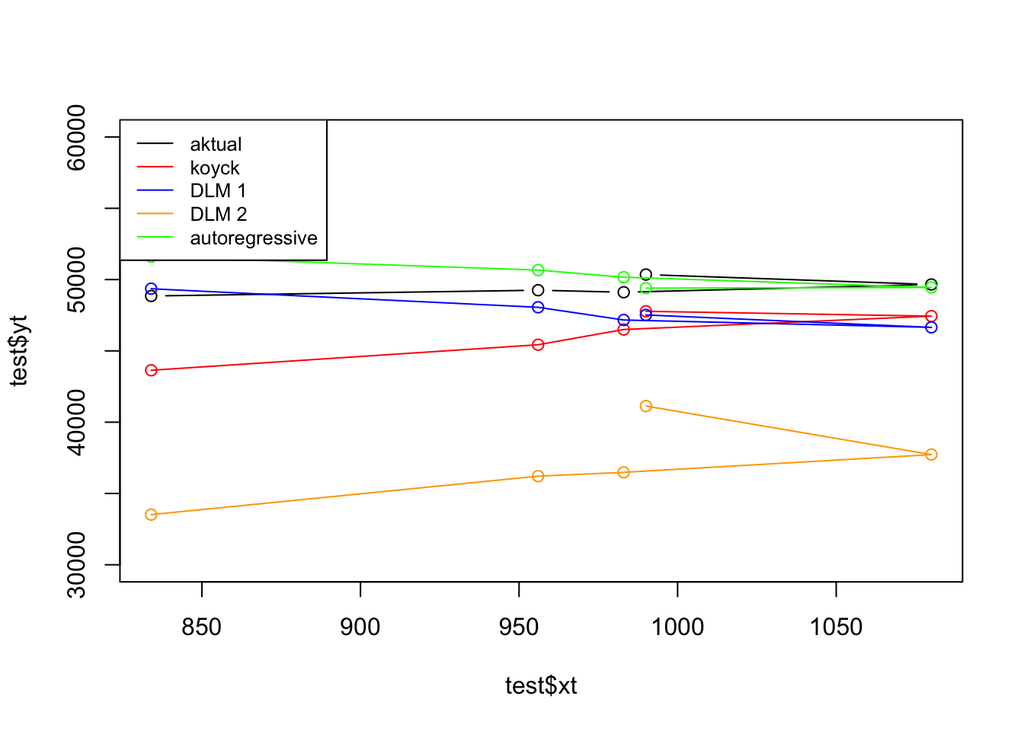

```r
par(mfrow=c(1,1))
plot(test$xt, test$yt, type="b", col="black", ylim=c(30000,60000))
points(test$xt, fore.koyck$forecasts,col="red")
lines(test$xt, fore.koyck$forecasts,col="red")
points(test$xt, fore.dlm$forecasts,col="blue")
lines(test$xt, fore.dlm$forecasts,col="blue")
points(test$xt, fore.dlm2$forecasts,col="orange")
lines(test$xt, fore.dlm2$forecasts,col="orange")
points(test$xt, fore.ardl$forecasts,col="green")
lines(test$xt, fore.ardl$forecasts,col="green")
legend("topleft",c("aktual", "koyck","DLM 1","DLM 2", "autoregressive"), lty=1, col=c("black","red","blue","orange","green"), cex=0.8)
```

Berdasarkan plot tersebut, terlihat bahwa plot yang paling mendekati data aktualnya adalah model autogressive, sehingga dapat disimpulkan model terbaik dalam hal ini adalah model autogressive